# ncfdown: A R Markdown template for New College of Florida

Jennifer Lin - 27 April 2020

# Welcome

Welcome to `ncfdown`, a R Markdown template with the New College of Florida spirit. This theme was created using epuRate as a springboard.

If you are familiar with Markdown, feel free to go ahead and do regular Markdown things with this template. Below, I will demonstrate some of the features that you can use in R Markdown.

I assume that since you are here, you already have this package installed into your RStudio, but if not…

```r
library(devtools)
install_github("lin-jennifer/ncfdown")
library(ncfdown)
```

For this template, you have the option to show all the code or not. Simply go to the top of this document, click on the code button and select show or hide all code. You can also show and hide line by line.

For this demo, I use the `ncfdown`, `datasets` and `dplyr` packages.

```r
library(ncfdown)
library(datasets)
library(dplyr)
```

# A Breeze Intro to R Markdown

Here are some really quick things you can do in Markdown…

**Bold**

```
**Bold**
```

*Italicize*

```
*Italicize*
```

I will let R Studio show you the rest: https://rstudio.com/wp-content/uploads/2015/02/rmarkdown-cheatsheet.pdf

# Plotting Data

```r
data("iris")
```

Let’s load the `iris` data from the `datasets` package and view it.

```r
head(iris)
```

|  | Sepal.Length | Sepal.Width | Petal.Length | Petal.Width | Species |
| --- | --- | --- | --- | --- | --- |
| 1 | 5.1 | 3.5 | 1.4 | 0.2 | setosa |
| 2 | 4.9 | 3.0 | 1.4 | 0.2 | setosa |
| 3 | 4.7 | 3.2 | 1.3 | 0.2 | setosa |
| 4 | 4.6 | 3.1 | 1.5 | 0.2 | setosa |
| 5 | 5.0 | 3.6 | 1.4 | 0.2 | setosa |
| 6 | 5.4 | 3.9 | 1.7 | 0.4 | setosa |

Let’s plot sepal length and width for setosa species

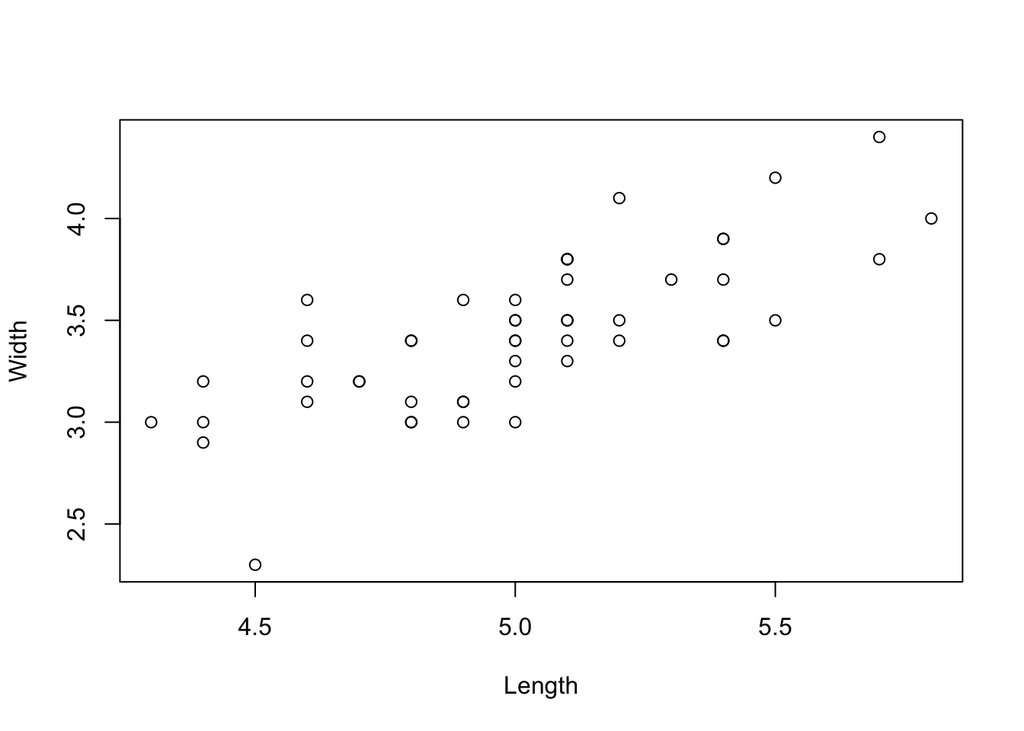

```r
iris <- iris %>% filter(Species == "setosa")
plot(iris$Sepal.Length, iris$Sepal.Width,
     xlab = "Length", ylab = "Width")
```

# Conclusions

Have feedback on this template? Please reach out at jenniferlin2025@u.northwestern.edu.

A work by [Jennifer Lin](https://github.com/lin-jennifer)

*jenniferlin2025@u.northwestern.edu*